# Proyecto 3, Avance 1

Micaela Yataz (carnet: 18960)

Edman Cota (carnet: 19830)

Edwin de Leon (carnet: 22809)

2025-03-22

https://github.com/edman-cota/proyecto3MD.git

# Cargar Datos

```r
# Cargar el archivo CSV en lugar de SAV
data <- read.csv("mortalidad.csv")

# Ver las primeras filas para entender la estructura
head(data)
```

```
##   Depreg Mupreg Mesreg Añoreg Depocu Mupocu Sexo Diaocu Mesocu Añoocu Edadif
## 1     13   1301      5   2022     13   1301    1     17      5   2022     39
## 2     13   1318      9   2022     13   1318    2     17      8   2022     33
## 3     13   1301      6   2022     13   1301    1      2      6   2022     39
## 4     13   1326      4   2022     13   1326    2     22      4   2022     35
## 5     14   1420      2   2022     14   1420    1     17      1   2022     35
## 6     14   1420      5   2022     14   1420    2     13      5   2022     35
##   Perdif Puedif Ecidif Escodif Ciuodif Pnadif Dnadif Mnadif Nacdif Predif
## 1      3      5      1       2      92    484     23   2300    484    320
## 2      3      5      1       1      97    484     23   2300    484    320
## 3      3      5      2       2      92    484     23   2300    484    320
## 4      3      5      1       1      97    484     23   2300    484    320
## 5      3      5      1       1      97    484     23   2300    484    320
## 6      3      5      1       2      97    484     23   2300    484    320
##   Dredif Mredif Caudef Asist Ocur Cerdef
## 1     13   1315   X482     1    1      1
## 2     13   1318   O720     5    6      9
## 3     13   1326   X482     1    1      1
## 4     13   1326   W749     4    9      9
## 5     14   1420   W849     9    9      9
## 6     14   1420   C169     5    6      9
```

# **1. Descripción General del Conjunto de Datos**

El conjunto de datos a evaluar es tomado del instituto nacional de estadistica, INE. Corresponden a los registros de difunciones en Guatemala, contiene informacion de cada fallecimiento, como el año de fallecimiento, causa, entre otros.

```r
summary(data)
```

```
##      Depreg          Mupreg         Mesreg           Añoreg
##  Min.   : 1.00   Min.   : 101   Min.   : 1.000   Min.   :2022
##  1st Qu.: 1.00   1st Qu.: 103   1st Qu.: 3.000   1st Qu.:2022
##  Median : 9.00   Median : 901   Median : 6.000   Median :2022
##  Mean   : 8.74   Mean   : 880   Mean   : 6.279   Mean   :2022
##  3rd Qu.:14.00   3rd Qu.:1408   3rd Qu.: 9.000   3rd Qu.:2022
##  Max.   :22.00   Max.   :2217   Max.   :12.000   Max.   :2023
##      Depocu           Mupocu          Sexo           Diaocu
##  Min.   : 1.000   Min.   : 101   Min.   :1.000   Min.   : 1.00
##  1st Qu.: 1.000   1st Qu.: 115   1st Qu.:1.000   1st Qu.: 8.00
##  Median : 9.000   Median : 901   Median :1.000   Median :16.00
##  Mean   : 8.715   Mean   : 878   Mean   :1.451   Mean   :15.67
##  3rd Qu.:14.000   3rd Qu.:1406   3rd Qu.:2.000   3rd Qu.:23.00
##  Max.   :22.000   Max.   :2217   Max.   :2.000   Max.   :31.00
##      Mesocu           Añoocu         Edadif           Perdif
##  Min.   : 1.000   Min.   :2022   Min.   :  0.00   Min.   :1.000
##  1st Qu.: 3.000   1st Qu.:2022   1st Qu.: 40.00   1st Qu.:3.000
##  Median : 6.000   Median :2022   Median : 64.00   Median :3.000
##  Mean   : 6.375   Mean   :2022   Mean   : 60.44   Mean   :2.914
##  3rd Qu.: 9.000   3rd Qu.:2022   3rd Qu.: 79.00   3rd Qu.:3.000
##  Max.   :12.000   Max.   :2022   Max.   :999.00   Max.   :9.000
##      Puedif          Ecidif         Escodif         Ciuodif
##  Min.   :1.000   Min.   :1.000   Min.   :1.000   Min.   : 1.00
##  1st Qu.:1.000   1st Qu.:1.000   1st Qu.:1.000   1st Qu.:92.00
##  Median :4.000   Median :1.000   Median :2.000   Median :97.00
##  Mean   :3.961   Mean   :1.463   Mean   :2.151   Mean   :88.45
##  3rd Qu.:4.000   3rd Qu.:2.000   3rd Qu.:2.000   3rd Qu.:97.00
##  Max.   :9.000   Max.   :9.000   Max.   :9.000   Max.   :99.00
##      Pnadif           Dnadif          Mnadif         Nacdif
##  Min.   :  32.0   Min.   : 1.00   Min.   : 101   Min.   :  32.0
##  1st Qu.: 320.0   1st Qu.: 5.00   1st Qu.: 501   1st Qu.: 320.0
##  Median : 320.0   Median :10.00   Median :1014   Median : 320.0
##  Mean   : 353.2   Mean   :10.58   Mean   :1065   Mean   : 353.2
##  3rd Qu.: 320.0   3rd Qu.:15.00   3rd Qu.:1508   3rd Qu.: 320.0
##  Max.   :9999.0   Max.   :99.00   Max.   :9999   Max.   :9999.0
##      Predif         Dredif         Mredif        Caudef
##  Min.   :  84   Min.   : 1.0   Min.   : 101   Length:95386
##  1st Qu.: 320   1st Qu.: 3.0   1st Qu.: 309   Class :character
##  Median : 320   Median :10.0   Median :1012   Mode  :character
##  Mean   :1250   Mean   :17.8   Mean   :1797
##  3rd Qu.: 320   3rd Qu.:16.0   3rd Qu.:1613
##  Max.   :9999   Max.   :99.0   Max.   :9999
##      Asist            Ocur           Cerdef
##  Min.   :1.000   Min.   :1.000   Min.   :1.000
##  1st Qu.:1.000   1st Qu.:4.000   1st Qu.:1.000
##  Median :4.000   Median :6.000   Median :9.000
##  Mean   :3.196   Mean   :5.023   Mean   :5.137
##  3rd Qu.:5.000   3rd Qu.:6.000   3rd Qu.:9.000
##  Max.   :9.000   Max.   :9.000   Max.   :9.000
```

# **2. Significado y Tipo de Variables**

```r
# Usar variables reales del dataset
variables <- c(
  "Departamento de registro",
  "Municipio de registro",
  "Mes de registro",
  "Año de registro",
  "Departamento de ocurrencia",
  "Municipio de ocurrencia",
  "Sexo del difunto(a)",
  "Día de ocurrencia",
  "Mes de ocurrencia",
  "Año ocurrencia",
  "Edad del difunto(a)",
  "Periodo de edad del difunto(a)",
  "Pueblo de pertenencia del difunto(a)",
  "Estado civil del difunto(a)",
  "Escolaridad del difunto(a)",
  "Ocupación (Subgrupos CIUO-08) del difunto(a)",
  "País de nacimiento del difunto(a)",
  "Departamento de nacimiento del difunto(a)",
  "Municipio de nacimiento del difunto(a)",
  "Nacionalidad del difunto(a)",
  "País de residencia del difunto(a)",
  "Departamento de residencia del difunto(a)",
  "Municipio de residencia del difunto(a)",
  "Causa de defunción",
  "Asistencia recibida",
  "Sitio de ocurrencia",
  "Quien certifica"
)

# Filtrar solo las variables de interés
datos_filtrados <- data %>% select(any_of(variables))

# Descripción y tipo de cada variable
descripcion <- c(
  "Departamento donde se registró el fallecimiento",
  "Municipio donde se registró el fallecimiento",
  "Mes en que se registró el fallecimiento",
  "Año en que se registró el fallecimiento",
  "Departamento donde ocurrió el fallecimiento",
  "Municipio donde ocurrió el fallecimiento",
  "Sexo biológico del fallecido(a)",
  "Día en que ocurrió el fallecimiento",
  "Mes en que ocurrió el fallecimiento",
  "Año en que ocurrió el fallecimiento",
  "Edad del fallecido(a) en años",
  "Rango de edad del fallecido(a)",
  "Pueblo indígena o comunidad a la que pertenecía",
  "Estado civil del fallecido(a)",
  "Nivel educativo alcanzado",
  "Ocupación según la clasificación CIUO-08",
  "País de nacimiento del fallecido(a)",
  "Departamento de nacimiento del fallecido(a)",
  "Municipio de nacimiento del fallecido(a)",
  "Nacionalidad del fallecido(a)",
  "País de residencia habitual del fallecido(a)",
  "Departamento de residencia habitual",
  "Municipio de residencia habitual",
  "Causa de la defunción",
  "Si recibió asistencia médica antes de fallecer",
  "Lugar donde ocurrió la defunción",
  "Persona o entidad que certificó la defunción"
)

tipo <- c(
  "Cualitativa nominal",
  "Cualitativa nominal",
  "Cuantitativa discreta",
  "Cuantitativa discreta",
  "Cualitativa nominal",
  "Cualitativa nominal",
  "Cualitativa nominal",
  "Cuantitativa discreta",
  "Cuantitativa discreta",
  "Cuantitativa discreta",
  "Cuantitativa discreta",
  "Cualitativa ordinal",
  "Cualitativa nominal",
  "Cualitativa nominal",
  "Cualitativa ordinal",
  "Cualitativa nominal",
  "Cualitativa nominal",
  "Cualitativa nominal",
  "Cualitativa nominal",
  "Cualitativa nominal",
  "Cualitativa nominal",
  "Cualitativa nominal",
  "Cualitativa nominal",
  "Cualitativa nominal",
  "Cualitativa nominal",
  "Cualitativa nominal",
  "Cualitativa nominal"
)

# Crear tabla con la información de las variables
tabla_variables <- data.frame(Variable = variables, Descripción = descripcion, Tipo = tipo)

# Imprimir la tabla
print(tabla_variables)
```

```
##                                        Variable
## 1                      Departamento de registro
## 2                         Municipio de registro
## 3                               Mes de registro
## 4                               Año de registro
## 5                    Departamento de ocurrencia
## 6                       Municipio de ocurrencia
## 7                           Sexo del difunto(a)
## 8                             Día de ocurrencia
## 9                             Mes de ocurrencia
## 10                               Año ocurrencia
## 11                          Edad del difunto(a)
## 12               Periodo de edad del difunto(a)
## 13         Pueblo de pertenencia del difunto(a)
## 14                  Estado civil del difunto(a)
```

[output cut: 41 more lines]

# **3. Cantidad de Variables y Observaciones**

```r
num_variables <- ncol(data)
num_observaciones <- nrow(data)
cat("Número de variables:", num_variables, "\n")
```

```
## Número de variables: 27
```

```r
cat("Número de observaciones:", num_observaciones, "\n")
```

```
## Número de observaciones: 95386
```

# **4. Exploración de Variables Numéricas**

## **Resumen Estadístico**

Se presenta una vision general de las variables numericas del conjunto de datos de defunciones, incluyendo las medidas de tendencia central, dispersion, etc.

```r
numeric_vars <- data %>% select(where(is.numeric))
summary(numeric_vars)
```

```
##      Depreg          Mupreg         Mesreg           Añoreg
##  Min.   : 1.00   Min.   : 101   Min.   : 1.000   Min.   :2022
##  1st Qu.: 1.00   1st Qu.: 103   1st Qu.: 3.000   1st Qu.:2022
##  Median : 9.00   Median : 901   Median : 6.000   Median :2022
##  Mean   : 8.74   Mean   : 880   Mean   : 6.279   Mean   :2022
##  3rd Qu.:14.00   3rd Qu.:1408   3rd Qu.: 9.000   3rd Qu.:2022
##  Max.   :22.00   Max.   :2217   Max.   :12.000   Max.   :2023
##      Depocu           Mupocu          Sexo           Diaocu
##  Min.   : 1.000   Min.   : 101   Min.   :1.000   Min.   : 1.00
##  1st Qu.: 1.000   1st Qu.: 115   1st Qu.:1.000   1st Qu.: 8.00
##  Median : 9.000   Median : 901   Median :1.000   Median :16.00
##  Mean   : 8.715   Mean   : 878   Mean   :1.451   Mean   :15.67
##  3rd Qu.:14.000   3rd Qu.:1406   3rd Qu.:2.000   3rd Qu.:23.00
##  Max.   :22.000   Max.   :2217   Max.   :2.000   Max.   :31.00
##      Mesocu           Añoocu         Edadif           Perdif
##  Min.   : 1.000   Min.   :2022   Min.   :  0.00   Min.   :1.000
##  1st Qu.: 3.000   1st Qu.:2022   1st Qu.: 40.00   1st Qu.:3.000
##  Median : 6.000   Median :2022   Median : 64.00   Median :3.000
##  Mean   : 6.375   Mean   :2022   Mean   : 60.44   Mean   :2.914
##  3rd Qu.: 9.000   3rd Qu.:2022   3rd Qu.: 79.00   3rd Qu.:3.000
##  Max.   :12.000   Max.   :2022   Max.   :999.00   Max.   :9.000
##      Puedif          Ecidif         Escodif         Ciuodif
##  Min.   :1.000   Min.   :1.000   Min.   :1.000   Min.   : 1.00
##  1st Qu.:1.000   1st Qu.:1.000   1st Qu.:1.000   1st Qu.:92.00
##  Median :4.000   Median :1.000   Median :2.000   Median :97.00
##  Mean   :3.961   Mean   :1.463   Mean   :2.151   Mean   :88.45
##  3rd Qu.:4.000   3rd Qu.:2.000   3rd Qu.:2.000   3rd Qu.:97.00
##  Max.   :9.000   Max.   :9.000   Max.   :9.000   Max.   :99.00
##      Pnadif           Dnadif          Mnadif         Nacdif
##  Min.   :  32.0   Min.   : 1.00   Min.   : 101   Min.   :  32.0
##  1st Qu.: 320.0   1st Qu.: 5.00   1st Qu.: 501   1st Qu.: 320.0
##  Median : 320.0   Median :10.00   Median :1014   Median : 320.0
##  Mean   : 353.2   Mean   :10.58   Mean   :1065   Mean   : 353.2
##  3rd Qu.: 320.0   3rd Qu.:15.00   3rd Qu.:1508   3rd Qu.: 320.0
##  Max.   :9999.0   Max.   :99.00   Max.   :9999   Max.   :9999.0
##      Predif         Dredif         Mredif         Asist            Ocur
##  Min.   :  84   Min.   : 1.0   Min.   : 101   Min.   :1.000   Min.   :1.000
##  1st Qu.: 320   1st Qu.: 3.0   1st Qu.: 309   1st Qu.:1.000   1st Qu.:4.000
##  Median : 320   Median :10.0   Median :1012   Median :4.000   Median :6.000
##  Mean   :1250   Mean   :17.8   Mean   :1797   Mean   :3.196   Mean   :5.023
##  3rd Qu.: 320   3rd Qu.:16.0   3rd Qu.:1613   3rd Qu.:5.000   3rd Qu.:6.000
##  Max.   :9999   Max.   :99.0   Max.   :9999   Max.   :9.000   Max.   :9.000
##      Cerdef
##  Min.   :1.000
##  1st Qu.:1.000
##  Median :9.000
##  Mean   :5.137
##  3rd Qu.:9.000
##  Max.   :9.000
```

Mesreg, Mesocu y Diaocu, son los meses, dias de difuncion, en el cual se puede hacer analisis y ver si hay una temporada con mas indices de defunciones y realcionalo por eventos especificos. AñoregÑ muestra que la mayoria de difuncioes se realizaron en el año 2022, lo cual puede ser por inclusion de registros recientes o por la pandemia.  
Sexo: registrada como 1 y 2 con media de 1.45 con el 1 lo cual indica mayor defunciones por este genero, lo cual se puede analizar para diferencia en mortalidad entre generos. Edadif: el rango va desde 0 a 999, donde el menor es 0, que indica muerte infantil, lo cual es conciderable para analisis de mortalidad infantil, la mediana es de 64 años, por lo que hay mayor difunciones en edades mayores

## **Medidas de Tendencia Central**

```r
get_mode <- function(x) {
  unique_x <- na.omit(unique(x))
  unique_x[which.max(tabulate(match(x, unique_x)))]

}

medidas_tendencia <- data.frame(
  Variable = names(numeric_vars),
  Media = sapply(numeric_vars, mean, na.rm = TRUE),
  Mediana = sapply(numeric_vars, median, na.rm = TRUE),
  Moda = sapply(numeric_vars, get_mode)
)

print(medidas_tendencia)
```

```
##         Variable       Media Mediana Moda
## Depreg    Depreg    8.739962       9    1
## Mupreg    Mupreg  879.967815     901  101
## Mesreg    Mesreg    6.279192       6    1
## Añoreg    Añoreg 2022.034449    2022 2022
## Depocu    Depocu    8.715136       9    1
## Mupocu    Mupocu  877.955172     901  101
## Sexo        Sexo    1.451052       1    1
## Diaocu    Diaocu   15.665758      16    6
## Mesocu    Mesocu    6.375202       6    1
## Añoocu    Añoocu 2022.000000    2022 2022
## Edadif    Edadif   60.441679      64    1
## Perdif    Perdif    2.914201       3    3
## Puedif    Puedif    3.960529       4    4
## Ecidif    Ecidif    1.463496       1    1
## Escodif  Escodif    2.151343       2    1
## Ciuodif  Ciuodif   88.453777      97   97
## Pnadif    Pnadif  353.216940     320  320
## Dnadif    Dnadif   10.581972      10    1
## Mnadif    Mnadif 1065.397868    1014  101
## Nacdif    Nacdif  353.216940     320  320
## Predif    Predif 1249.862087     320  320
## Dredif    Dredif   17.804835      10    1
## Mredif    Mredif 1796.716866    1012 9999
## Asist      Asist    3.195836       4    1
## Ocur        Ocur    5.023274       6    6
## Cerdef    Cerdef    5.137158       9    9
```

La variable de año de difuncion presenta una mediana de 2022 y una moda de 2022 lo cual indica que la mayoria de registro de difuncion se relaizaron el en el 2022.

La variable como sexo, tiene como media 1.45 y mediana 1, la cual indicaria que las defunciones registradas con en gran parte del genero que representa el genero 1.

## **Distribución de Variables Numéricas**

### Histogramas

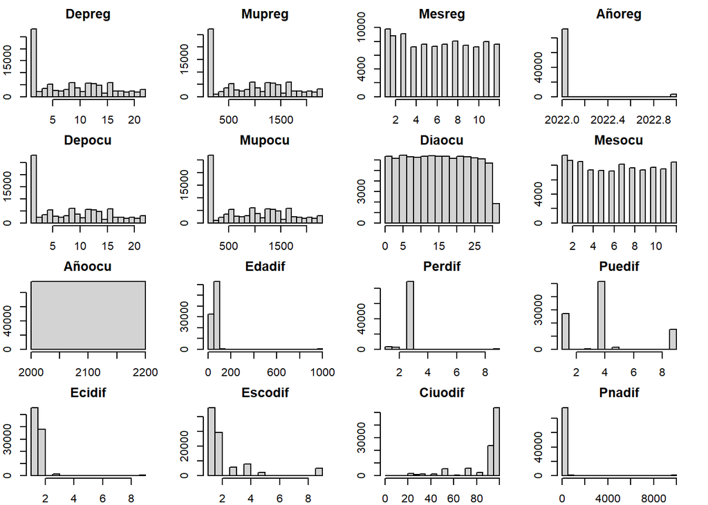

```r
# Establecer la disposición de los gráficos (para mostrar varios a la vez)

par(mfrow = c(4, 4), mar = c(2, 2, 2, 2)) # Márgenes más pequeños

# Crear histogramas para cada variable numérica
hist(data$Depreg, main = "Depreg", xlab = "Valor")
hist(data$Mupreg, main = "Mupreg", xlab = "Valor")
hist(data$Mesreg, main = "Mesreg", xlab = "Valor")
hist(data$Añoreg, main = "Añoreg", xlab = "Valor")
hist(data$Depocu, main = "Depocu", xlab = "Valor")
hist(data$Mupocu, main = "Mupocu", xlab = "Valor")
hist(data$Diaocu, main = "Diaocu", xlab = "Valor")
hist(data$Mesocu, main = "Mesocu", xlab = "Valor")
hist(data$Añoocu, main = "Añoocu", xlab = "Valor")
hist(data$Edadif, main = "Edadif", xlab = "Valor")
hist(data$Perdif, main = "Perdif", xlab = "Valor")
hist(data$Puedif, main = "Puedif", xlab = "Valor")
hist(data$Ecidif, main = "Ecidif", xlab = "Valor")
hist(data$Escodif, main = "Escodif", xlab = "Valor")
hist(data$Ciuodif, main = "Ciuodif", xlab = "Valor")
hist(data$Pnadif, main = "Pnadif", xlab = "Valor")
```

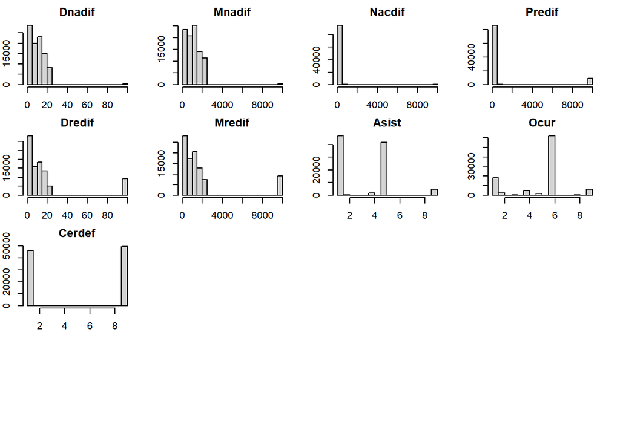

```r
hist(data$Dnadif, main = "Dnadif", xlab = "Valor")
hist(data$Mnadif, main = "Mnadif", xlab = "Valor")
hist(data$Nacdif, main = "Nacdif", xlab = "Valor")
hist(data$Predif, main = "Predif", xlab = "Valor")
hist(data$Dredif, main = "Dredif", xlab = "Valor")
hist(data$Mredif, main = "Mredif", xlab = "Valor")
hist(data$Asist, main = "Asist", xlab = "Valor")
hist(data$Ocur, main = "Ocur", xlab = "Valor")
hist(data$Cerdef, main = "Cerdef", xlab = "Valor")

# Restablecer la disposición de los gráficos
par(mfrow = c(1, 1))
```

Las variables Mesreg, Diaocu, Mesocu muetran una distribucion de relativamente uniforme. Edadif, hay asimetria a la derecha, lo cual puede indicar el que hay mas muertes en personas de edades avanzadas Pnadif, Puedif, muestran valores atipicos. Depreg, Depocu, la distribucion es desigual, por lo que hay departamentos con mas indices de ocurrencia mas alta.

### Boxplots

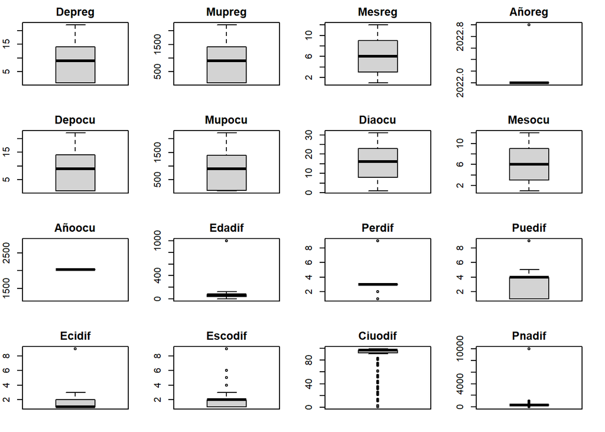

```r
# Establecer la disposición de los gráficos (para mostrar varios a la vez)
par(mfrow = c(4, 4), mar = c(2, 2, 2, 2)) # Márgenes más pequeños

# Crear boxplots para cada variable numérica
boxplot(data$Depreg, main = "Depreg", ylab = "Valor")
boxplot(data$Mupreg, main = "Mupreg", ylab = "Valor")
boxplot(data$Mesreg, main = "Mesreg", ylab = "Valor")
boxplot(data$Añoreg, main = "Añoreg", ylab = "Valor")
boxplot(data$Depocu, main = "Depocu", ylab = "Valor")
boxplot(data$Mupocu, main = "Mupocu", ylab = "Valor")
boxplot(data$Diaocu, main = "Diaocu", ylab = "Valor")
boxplot(data$Mesocu, main = "Mesocu", ylab = "Valor")
boxplot(data$Añoocu, main = "Añoocu", ylab = "Valor")
boxplot(data$Edadif, main = "Edadif", ylab = "Valor")
boxplot(data$Perdif, main = "Perdif", ylab = "Valor")
boxplot(data$Puedif, main = "Puedif", ylab = "Valor")
boxplot(data$Ecidif, main = "Ecidif", ylab = "Valor")
boxplot(data$Escodif, main = "Escodif", ylab = "Valor")
boxplot(data$Ciuodif, main = "Ciuodif", ylab = "Valor")
boxplot(data$Pnadif, main = "Pnadif", ylab = "Valor")
```

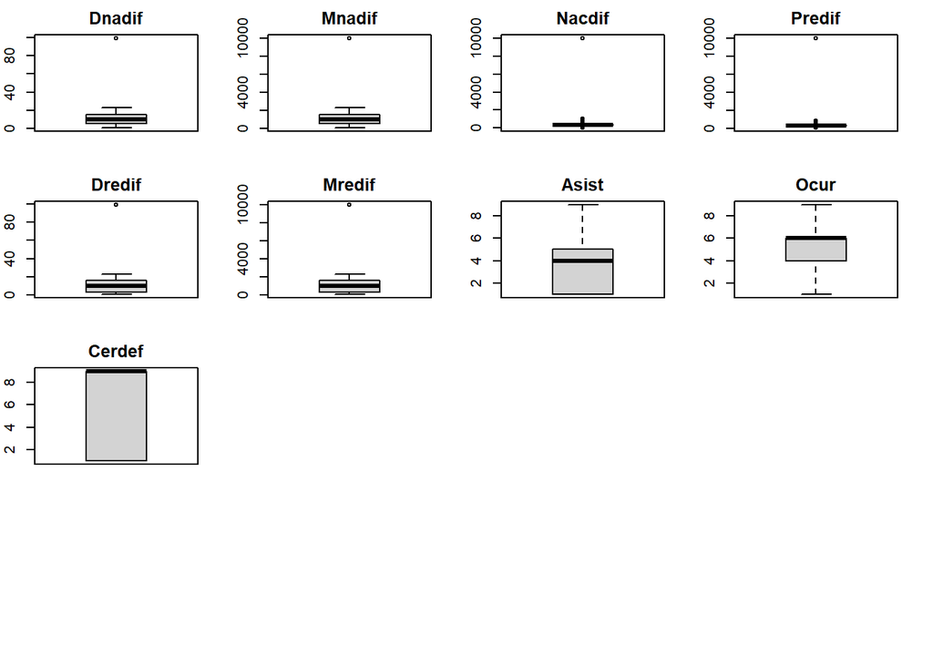

```r
boxplot(data$Dnadif, main = "Dnadif", ylab = "Valor")
boxplot(data$Mnadif, main = "Mnadif", ylab = "Valor")
boxplot(data$Nacdif, main = "Nacdif", ylab = "Valor")
boxplot(data$Predif, main = "Predif", ylab = "Valor")
boxplot(data$Dredif, main = "Dredif", ylab = "Valor")
boxplot(data$Mredif, main = "Mredif", ylab = "Valor")
boxplot(data$Asist, main = "Asist", ylab = "Valor")
boxplot(data$Ocur, main = "Ocur", ylab = "Valor")
boxplot(data$Cerdef, main = "Cerdef", ylab = "Valor")

# Restablecer la disposición de los gráficos
par(mfrow = c(1, 1))
```

En Mupreg, Mupocu hay distribucion sesgada, por lo que puede indicar valores altos, por lo que puede haber municipios con mayor registro de defuncion

Añoreg, Añoocu hay distribucion concentrada en un solo punto, lo cual confirma que la mayoria de registros de defucion se han hecho en 2022

Edadif, confirmando la mayor concentracion en las edades avanzadas.

Ecidif, muestra disftribucion sesgada la mayoria de los valores concentrados en el exteremo inferior del rango, por lo que la mayoria de difunciones ocurre en personas con un estado civil especifico.

# **5. Exploración de Variables Categóricas**

```r
categorical_vars <- c("Depreg", "Sexo", "Caudef")

for (var in categorical_vars) {
  cat("\nFrecuencia de", var, ":\n")
  print(table(data[[var]]))

  ggplot(data, aes_string(x = var)) +
    geom_bar(fill = "steelblue", color = "black", alpha = 0.7) +
    theme_minimal() +
    labs(title = paste("Distribución de", var), x = var, y = "Frecuencia") +
    theme(axis.text.x = element_text(angle = 45, hjust = 1))
}
```

```
##
## Frecuencia de Depreg :
##
##     1     2     3     4     5     6     7     8     9    10    11    12    13
## 27255   924  2044  3489  5215  2654  2345  2961  5774  3641  2135  5642  5471
##    14    15    16    17    18    19    20    21    22
##  4805  1499  5804  2343  2295  1847  2321  1868  3054
```

[output not shown]

[output cut: 141 more lines]

[output not shown]

# **6. Relaciones entre Variables**

## **Análisis de Correlación**

```r
cor_matrix <- cor(numeric_vars, use = "complete.obs")
print("Matriz de correlación:")
```

```
## [1] "Matriz de correlación:"
```

```r
print(cor_matrix)
```

```
##               Depreg       Mupreg       Mesreg        Añoreg       Depocu
## Depreg   1.000000000  0.999957341 -0.016121408  0.1038092800  0.978296064
## Mupreg   0.999957341  1.000000000 -0.016256708  0.1042718866  0.978257694
## Mesreg  -0.016121408 -0.016256708  1.000000000 -0.2557081428 -0.015382202
## Añoreg   0.103809280  0.104271887 -0.255708143  1.0000000000  0.104643505
## Depocu   0.978296064  0.978257694 -0.015382202  0.1046435054  1.000000000
## Mupocu   0.978249996  0.978281823 -0.015473552  0.1050410829  0.999954848
## Sexo     0.009483753  0.009461320  0.003885393 -0.0002489787  0.008351635
## Diaocu  -0.005099682 -0.005134610  0.001776504  0.1111530602 -0.004092108
## Mesocu  -0.003474745 -0.003546998  0.843612295  0.2568452452 -0.002472482
## Añoocu            NA           NA           NA            NA           NA
## Edadif  -0.011167204 -0.011151423 -0.017417549  0.0138061605 -0.009474360
## Perdif  -0.015016991 -0.014837826 -0.012567257  0.0054410710 -0.014316313
## Puedif  -0.087950126 -0.088873096  0.014954588 -0.0133727307 -0.087185181
## Ecidif  -0.041738471 -0.041967506 -0.007697019  0.0101564688 -0.037202001
## Escodif -0.156121096 -0.157009783  0.012153002 -0.0229794590 -0.154614602
## Ciuodif  0.152405979  0.153271663 -0.009019189  0.0350688874  0.151628152
## Pnadif  -0.025456493 -0.025709008 -0.004458942  0.0255840370 -0.023670548
## Dnadif   0.522898541  0.522226753 -0.009554100  0.0683353065  0.520621776
## Mnadif   0.521053458  0.520423328 -0.009614284  0.0684958798  0.518780040
## Nacdif  -0.025456493 -0.025709008 -0.004458942  0.0255840370 -0.023670548
## Predif   0.011010851  0.010861384  0.021371140  0.0225753333  0.011618670
## Dredif   0.206744273  0.206531087  0.017110700  0.0411087929  0.206197237
## Mredif   0.204963549  0.204765099  0.017136830  0.0410108611  0.204424594
## Asist    0.383426352  0.385600148 -0.014235815  0.0781797242  0.389520803
## Ocur     0.177370438  0.178906857 -0.010610238  0.0467480796  0.185481697
## Cerdef   0.430782523  0.433297297 -0.018513742  0.0879618121  0.435759783
##               Mupocu          Sexo        Diaocu       Mesocu Añoocu
## Depreg   0.978249996  0.0094837535 -0.0050996817 -0.003474745     NA
## Mupreg   0.978281823  0.0094613199 -0.0051346099 -0.003546998     NA
## Mesreg  -0.015473552  0.0038853934  0.0017765037  0.843612295     NA
## Añoreg   0.105041083 -0.0002489787  0.1111530602  0.256845245     NA
## Depocu   0.999954848  0.0083516348 -0.0040921077 -0.002472482     NA
## Mupocu   1.000000000  0.0083164603 -0.0041409504 -0.002523092     NA
## Sexo     0.008316460  1.0000000000  0.0012495855  0.005114123     NA
## Diaocu  -0.004140950  0.0012495855  1.0000000000  0.023557604     NA
## Mesocu  -0.002523092  0.0051141233  0.0235576040  1.000000000     NA
## Añoocu            NA            NA            NA           NA      1
## Edadif  -0.009262278  0.0395383914  0.0023535369 -0.014703733     NA
## Perdif  -0.013757537 -0.0132963838  0.0051021598 -0.010112928     NA
```

[output cut: 107 more lines]

```
## Perdif   0.088090417
## Puedif  -0.191732827
## Ecidif  -0.010489996
## Escodif -0.121375813
## Ciuodif  0.144235304
## Pnadif  -0.002333679
## Dnadif   0.177211354
## Mnadif   0.177759283
## Nacdif  -0.002333679
## Predif  -0.052028980
## Dredif   0.030646937
## Mredif   0.030208910
## Asist    0.911708842
## Ocur     0.559522207
## Cerdef   1.000000000
```

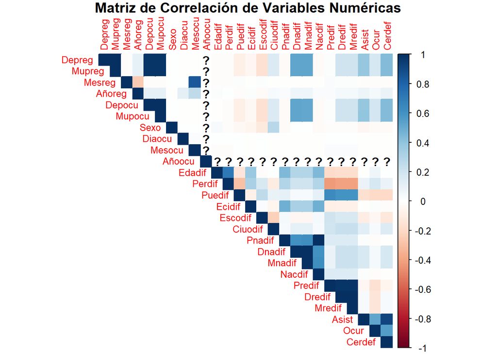

```r
# Visualización de la matriz de correlación
corrplot(cor_matrix, method = "color", type = "upper", tl.cex = 0.8,
         title = "Matriz de Correlación de Variables Numéricas", mar=c(0,0,1,0))
```